# Phylogenetic Analysis

Gepoliano Chaves

March 19th, 2024

# 1) Visualize alignment

## Load and process multi-fasta file from Bahia

Load package msa: multiple sequence alignment

```r
library("msa")
```

Load multi-fasta from Bahia. This file contains pangolin and bat sequences. This file is not aligned and we have another multi-fasta file called extremo_sul_muscle.fasta, that was aligned using MUSCLE.

```r
fastas_sars_cov2_ba <- readDNAStringSet(file="../dados/extremo_sul_combined/extremo_sul.fasta")
```

## Subset from positions 1bp to 350bp

Information about subsetting strings was gained from Chapter 4: Manipulating Sequences with Biostrings, found in Gatto (2023).

```r
seq_1_to_350 <- subseq(fastas_sars_cov2_ba, start = 1, end = 350)
```

Print sequence

```r
print(seq_1_to_350)
```

```
## DNAStringSet object of length 10:
##      width seq                                              names
##  [1]   350 ATTAAAGGTTTATACCTTCCCAG...CAGGTTCGCGACGTGCTCGTAC NC_045512.2 Wuhan...
##  [2]   350 ACTCTCGATCTCTTGTAGATCTG...CGTGGAGGAGGCTTTATCAGAG hCoV-19/bat/Yunna...
##  [3]   350 ACCAACCAACTTTCGATCTCTTG...GGAGACTCCGTGGAGGAGGTCT hCoV-19/Brazil/MG...
##  [4]   350 ACCAACTTTCGATCTCTTGTAGA...ACTCCGTGGAGGAGGTCTTATC hCoV-19/Brazil/BA...
##  [5]   350 ACCAACTTTCGATCTCTTGTAGA...ACTCCGTGGAGGAGGTCTTATC hCoV-19/Brazil/BA...
##  [6]   350 TTAAAATCTGTGTGGCTGTCACT...AGGATGGCACTTGTGGCTTAGT hCoV-19/pangolin/...
##  [7]   350 CTTTCGATCTCTTGTAGATCTGT...GTGGAGGAGGTCTTATCAGAGG hCoV-19/Brazil/BA...
##  [8]   350 CAACTTTCGATCTCTTGTAGATC...TCCGTGGAGGAGGTCTTATCAG hCoV-19/Brazil/BA...
##  [9]   350 ACTTTCGATCTCTTGTAGATCTG...CGTGGAGGAGGTCTTATCAGAG hCoV-19/Brazil/BA...
## [10]   350 TTCCCAGGTAACAAACCAACCAA...TCGTACGTGGCTTTGGAGACTC hCoV-19/Brazil/ES...
```

Align sequences

```r
start_time <- Sys.time()
alignment_ba_1_to_350 <- msa(seq_1_to_350)
```

```
## use default substitution matrix
```

```r
end_time <- Sys.time()
end_time - start_time
```

```
## Time difference of 0.14995 secs
```

```r
alignment_ba_1_to_350
```

```
## CLUSTAL 2.1
##
## Call:
##    msa(seq_1_to_350)
##
## MsaDNAMultipleAlignment with 10 rows and 426 columns
##      aln                                                   names
##  [1] ATTAAAGGTTTATACCTTCCCAGGT...------------------------- NC_045512.2 Wuhan...
##  [2] ----------------TTCCCAGGT...------------------------- hCoV-19/Brazil/ES...
##  [3] -------------------------...------------------------- hCoV-19/Brazil/MG...
##  [4] -------------------------...------------------------- hCoV-19/Brazil/BA...
##  [5] -------------------------...------------------------- hCoV-19/Brazil/BA...
##  [6] -------------------------...------------------------- hCoV-19/Brazil/BA...
##  [7] -------------------------...------------------------- hCoV-19/Brazil/BA...
##  [8] -------------------------...------------------------- hCoV-19/Brazil/BA...
##  [9] -------------------------...------------------------- hCoV-19/bat/Yunna...
## [10] -------------------------...TCAAGGATGGCACTTGTGGCTTAGT hCoV-19/pangolin/...
##  Con -------------------------...------------------------- Consensus
```

Export and import msa object

```r
saveRDS(multiple_fasta_almt_ba, file = "../dados/multiple_fasta_almt_ba.rds")
multiple_fasta_almt_ba_read <- readRDS("../dados/multiple_fasta_almt_ba.rds")
```

Print alignment

```r
msaPrettyPrint(alignment_ba_1_to_350, output="pdf", showNames="none",
               showLogo="none", askForOverwrite=FALSE, verbose=FALSE)
```

Print Logo

```r
msaPrettyPrint(alignment_ba_1_to_350, output="pdf",## y=c(164, 213),
               #subset=c(1:6),
               showNames="none", showLogo="top",
               logoColors="rasmol", shadingMode="similar",
               showLegend=FALSE, askForOverwrite=FALSE)
```

# 2) Distance Matrix and Phylogenetic Tree of Partial Sequence

This is necessary so function dist.ml can take the DNA.bin object and process the Distance Matrix. Function dist.ml() is from package phangorn

```r
library("phangorn")
dm_extremo_sul_msa_partial <- dist.ml(as.DNAbin(alignment_ba_1_to_350))
```

## Plot distance matrix

Function table.paint() is from package adegenet. Load library adegenet:

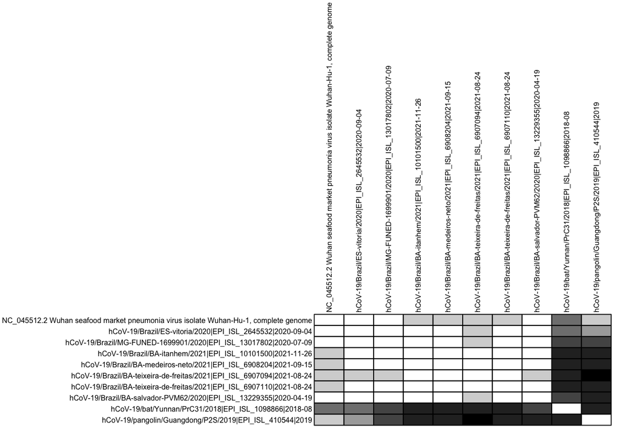

```r
library("adegenet")
dm_extremo_sul_msa_partial_df <- as.data.frame(as.matrix(dm_extremo_sul_msa_partial))
table.paint(dm_extremo_sul_msa_partial_df, cleg=0, clabel.row=.5, clabel.col=.5)
```

## Construct Phylogenetic Trees

Phylogenetic tree UPGMA method

```r
treeUPGMA_extremo_sul_partial <- upgma(dm_extremo_sul_msa_partial_df)
```

## Plot Phylogenetic Trees Extremo Sul

Plot UPGMA Extremo Sul

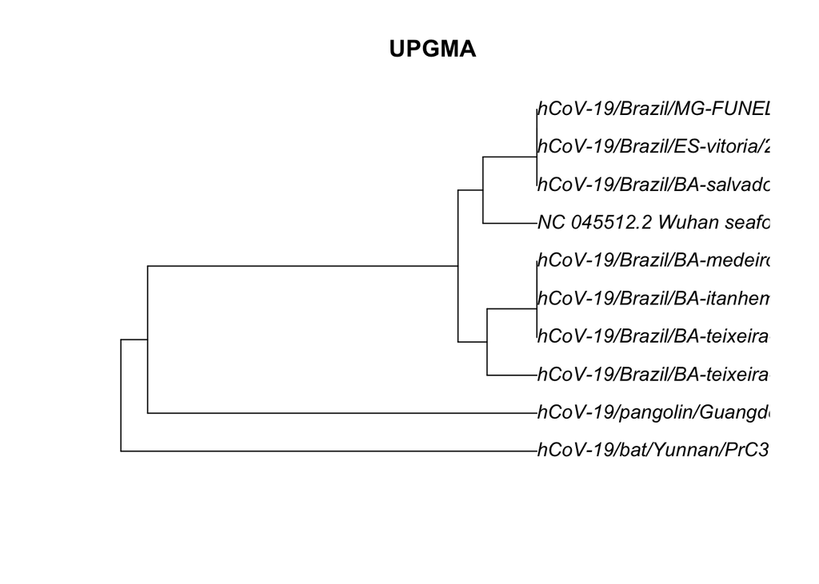

```r
plot(treeUPGMA_extremo_sul_partial, main="UPGMA", col="red")
```

# 3) Visualize Distance Matrix and Phylogenetic Tree of Complete Genome

## Coerce Biostring to DNA.bin

Read msa object that was exported

```r
multiple_fasta_almt_ba_read <- readRDS("../dados/multiple_fasta_almt_ba.rds")
```

This is necessary so function dist.ml can take the DNA.bin object and process the Distance Matrix. Function dist.ml() is from package phangorn

```r
library("phangorn")
dm_extremo_sul_msa_read <- dist.ml(as.DNAbin(multiple_fasta_almt_ba_read))
```

## Plot distance matrix

Function table.paint() is from package adegenet. Load library adegenet:

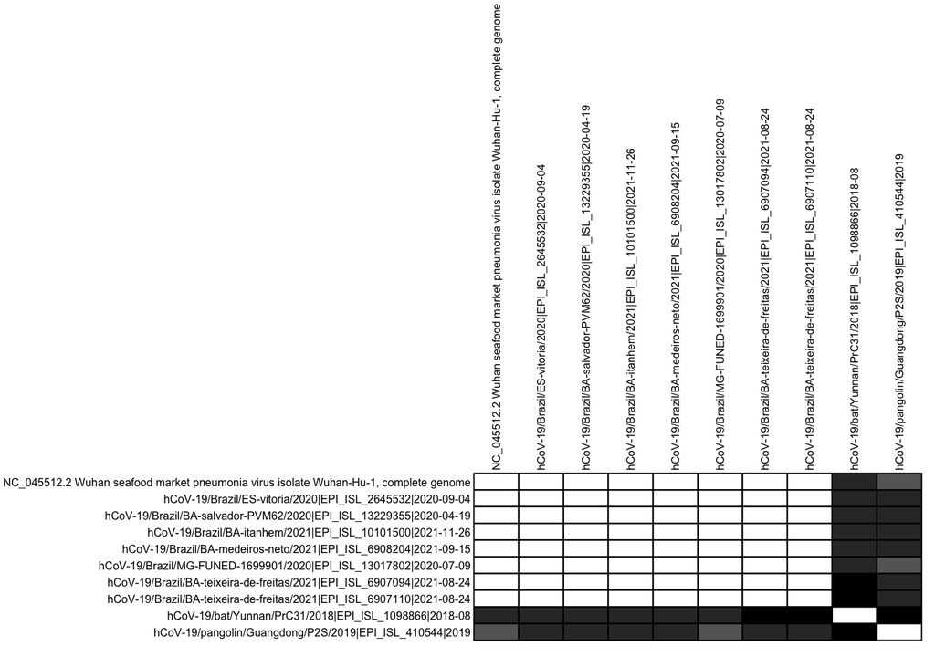

```r
library("adegenet")

dm_extremo_sul_msa_read_df <- as.data.frame(as.matrix(dm_extremo_sul_msa_read))
table.paint(dm_extremo_sul_msa_read_df, cleg=0, clabel.row=.5, clabel.col=.5)
```

## Construct Phylogenetic Trees

Phylogenetic tree UPGMA method

```r
treeUPGMA_extremo_sul <- upgma(dm_extremo_sul_msa_read_df)
```

## Plot Phylogenetic Trees Extremo Sul

Plot UPGMA Extremo Sul

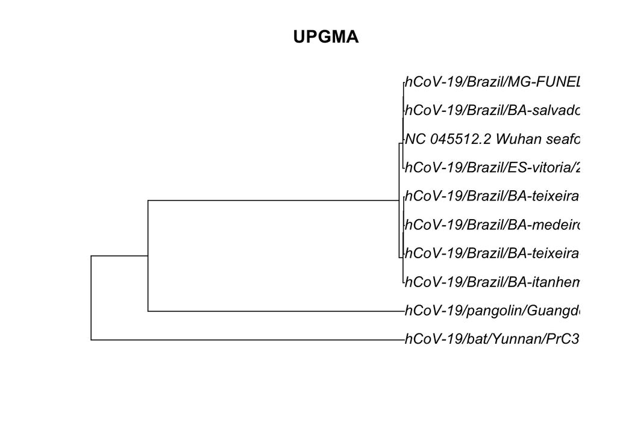

```r
plot(treeUPGMA_extremo_sul, main="UPGMA", col="red")
```

# 4) Visualize the Spike Protein Region

These positions match approximately the region that encodes the Spike Protein sequence

```r
seq_23000_to_29700 <- subseq(fastas_sars_cov2_ba, start = 23000, end = 29700)
```

### Align sequences region spike

```r
start_time <- Sys.time()
alignment_23000_to_29700 <- msa(seq_23000_to_29700)
```

```
## use default substitution matrix
```

```r
end_time <- Sys.time()
end_time - start_time
```

```
## Time difference of 38.68454 secs
```

```r
alignment_23000_to_29700
```

```
## CLUSTAL 2.1
##
## Call:
##    msa(seq_23000_to_29700)
##
## MsaDNAMultipleAlignment with 10 rows and 6827 columns
##      aln                                                   names
##  [1] TGTAATGGTGTTGAAGGTTTTAATT...------------------------- NC_045512.2 Wuhan...
##  [2] ----------------GTTTTAATT...------------------------- hCoV-19/Brazil/ES...
##  [3] -------------------------...------------------------- hCoV-19/Brazil/BA...
##  [4] -------------------------...------------------------- hCoV-19/Brazil/BA...
##  [5] -------------------------...------------------------- hCoV-19/Brazil/BA...
##  [6] -------------------------...------------------------- hCoV-19/Brazil/BA...
##  [7] -------------------------...------------------------- hCoV-19/Brazil/BA...
##  [8] -------------------------...------------------------- hCoV-19/Brazil/MG...
##  [9] -------------------------...AGAGCCCTAATGTGTAAAATTAATT hCoV-19/bat/Yunna...
## [10] -------------------------...------------------------- hCoV-19/pangolin/...
##  Con -------------------------...------------------------- Consensus
```

### Visualize Alignment Spike Protein

```r
msaPrettyPrint(alignment_23000_to_29700, output="pdf",## y=c(164, 213),
               #subset=c(1:6),
               showNames="none", showLogo="top",
               logoColors="rasmol", shadingMode="similar",
               showLegend=FALSE, askForOverwrite=FALSE)
```

### Visualize the Spike Region Alignment

#### Subset the Spike Protein Region in original multi-fasta sequence

```r
## Subset
seq_23000_to_23500 <- subseq(fastas_sars_cov2_ba, start = 23000, end = 23500)
## Align
alignment_23000_to_23500 <- msa(seq_23000_to_23500)
```

```
## use default substitution matrix
```

#### Visualize

```r
msaPrettyPrint(alignment_23000_to_23500, output="pdf",## y=c(164, 213),
               #subset=c(1:6),
               showNames="none", showLogo="top",
               logoColors="rasmol", shadingMode="similar",
               showLegend=FALSE, askForOverwrite=FALSE)
```

#### Save alignment as aligned fasta

```r
writeXStringSet(as(unmasked(alignment_23000_to_23500), "XStringSet"), file="../dados/alignment_23000_to_23500.fasta")
```

#### Read file as aligned fasta

```r
alignment_23000_to_23500_alnFasta <- readDNAStringSet(file="../dados/alignment_23000_to_23500.fasta")
```

## View Spike Protein Region

- Visualization of the Spike Protein Region alignment was made possible with library ggmsa and the work of Zhou (2022).
- Load library.

```r
library(ggmsa)
```

### SNP 23063 (N501Y)

```
## replace the existing one.
```

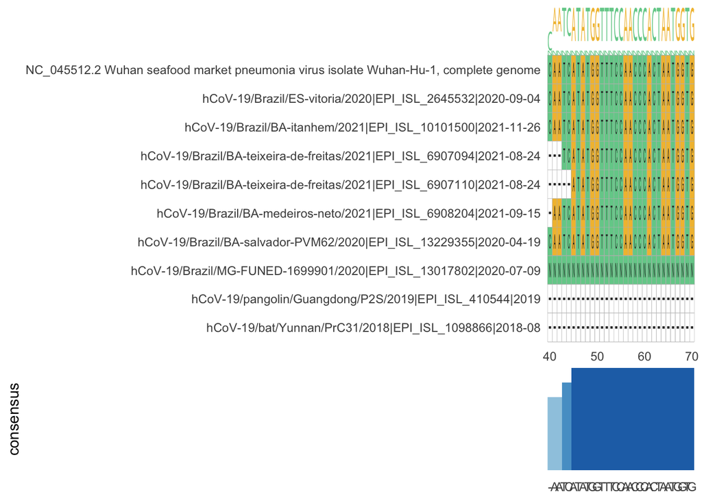

```r
ggmsa(alignment_23000_to_23500_alnFasta,
      start = 40, end = 70,
      char_width = 0.5,
      seq_name = T) + geom_seqlogo() + geom_msaBar()
```

- Plot without sequence names

```
## replace the existing one.
```

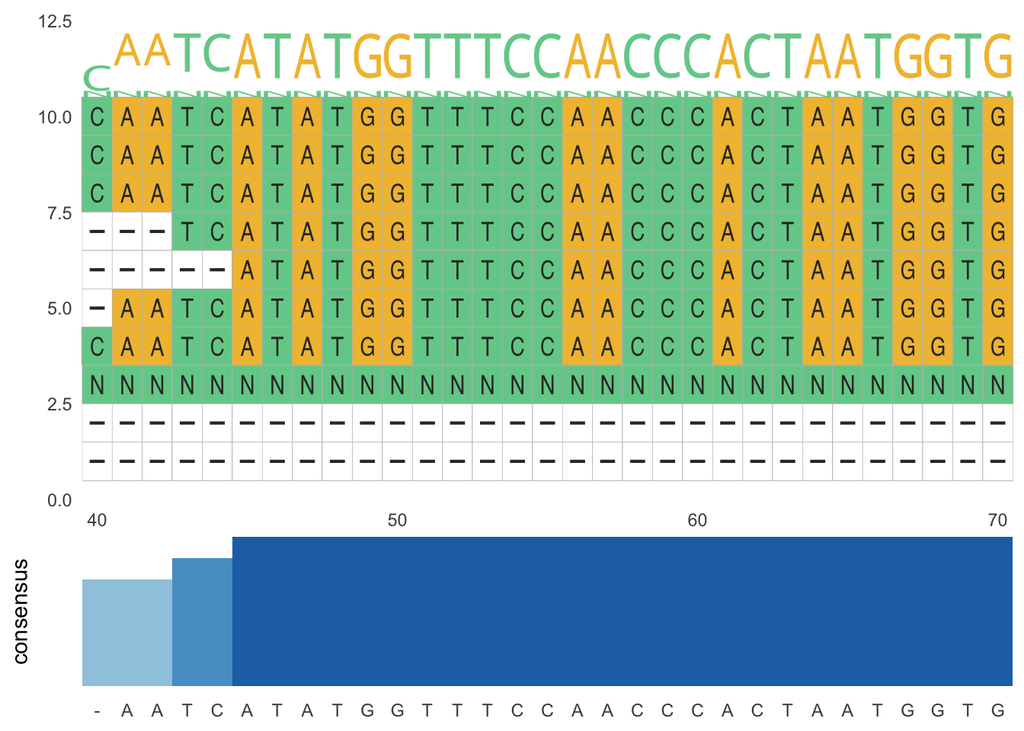

```r
ggmsa(alignment_23000_to_23500_alnFasta,
      start = 40, end = 70,
      char_width = 0.5,
      seq_name = F) + geom_seqlogo() + geom_msaBar()
```

### SNP 23404 (D614G)

```
## replace the existing one.
```

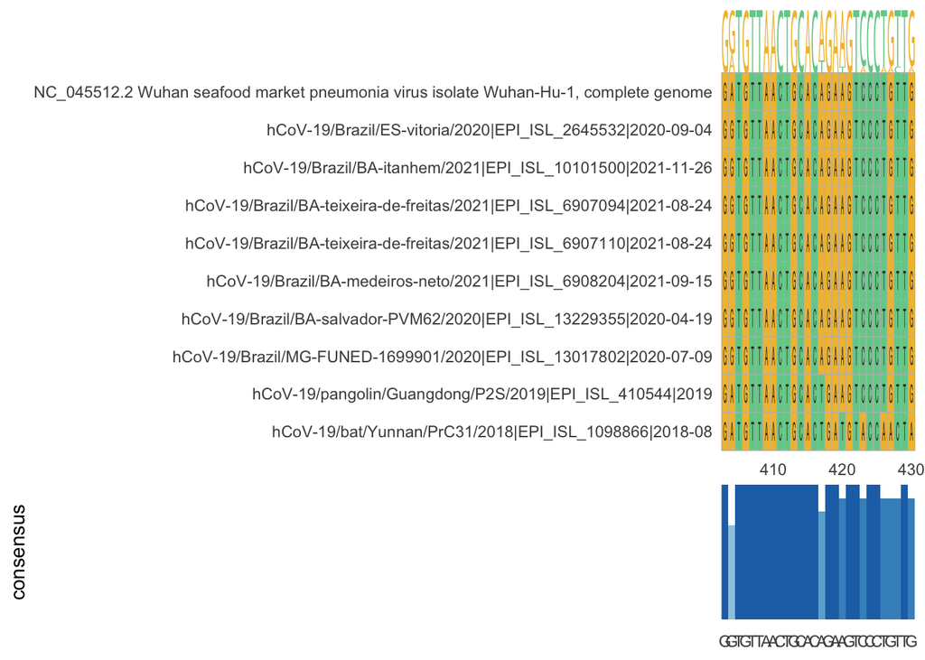

```r
ggmsa(alignment_23000_to_23500_alnFasta,
      start = 403,
      end = 430,
      char_width = 0.5,
      seq_name = T) + geom_seqlogo() + geom_msaBar()
```

- Plot without sequence names

```
## replace the existing one.
```

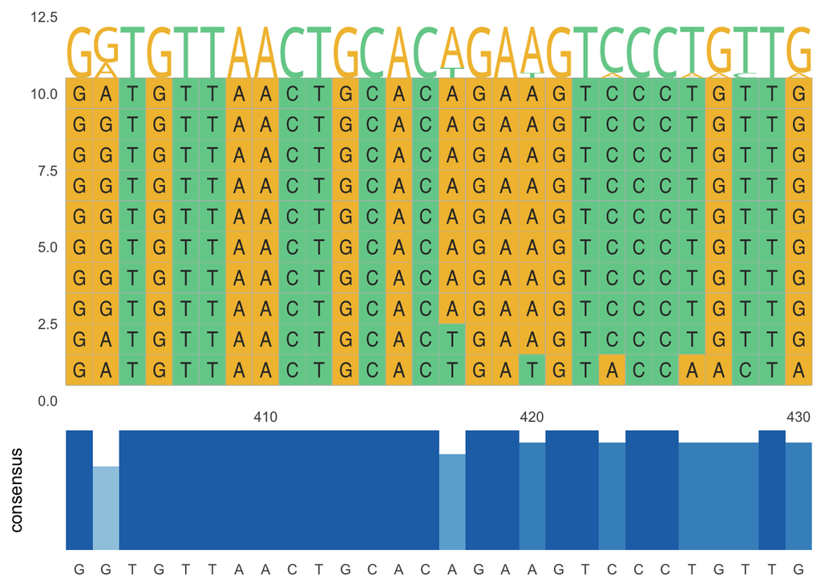

```r
ggmsa(alignment_23000_to_23500_alnFasta,
      start = 403,
      end = 430,
      char_width = 0.5,
      seq_name = F) + geom_seqlogo() + geom_msaBar()
```

## References

Gatto, Laurent. 2023. *Chapter 4 Manipulating Sequences with Biostrings*. https://uclouvain-cbio.github.io/WSBIM1322/sec-biostrings.html.

Zhou, Lang. 2022. *Ggmsa:a Visual Exploration Tool for Multiple Sequence Alignment and Associated Data*. http://yulab-smu.top/ggmsa/index.html.